# Data wrangling in Python - Data wrangling with NumPy - 1

One should look for what is and not what he thinks should be. (Albert Einstein)

# Data Wrangling with NumPy: Topic introduction

In this part of the course, we will cover the following concepts:

- NumPy use cases and object types
- NumPy array manipulation

# Warm up

- Have a look at the dataset to the right
- What **questions** do you have about it?
- What might make it **difficult** to work with?
- Share your thoughts in the chat or aloud

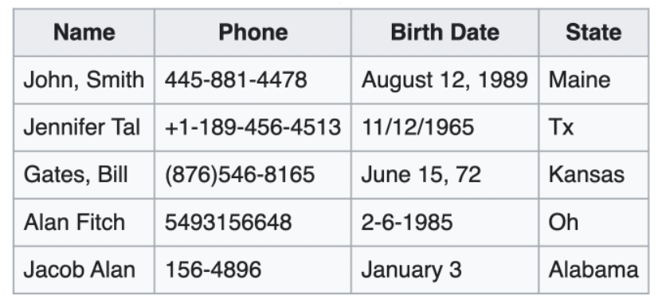

Source: [wikipedia](https://en.wikipedia.org/wiki/Data_wrangling#:~:text=Data%20wrangling%20typically%20follows%20a,for%20storage%20and%20future%20use)

# Importance of clean data

- In today’s session, we’re going to talk about how to **prepare and organize data**
- The process is also known as data cleaning and data wrangling

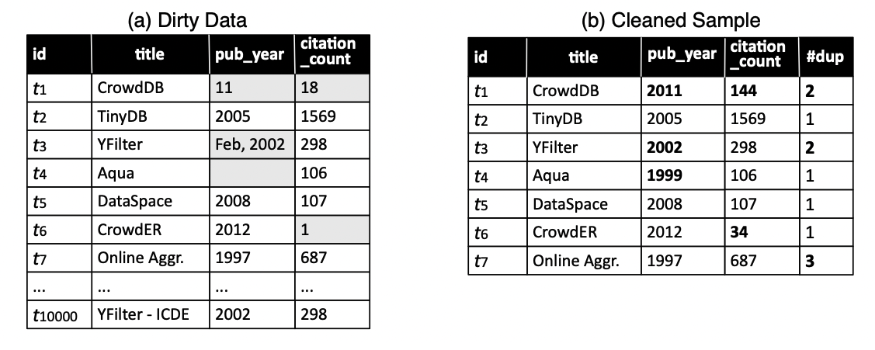

Source: [Semantic Scholar](https://www.semanticscholar.org/paper/A-sample-and-clean-framework-for-fast-and-accurate-Wang-Krishnan/f55b345477fee491ad68b4b2797499a34e06291e)

# Module completion checklist

In this module, we will explore NumPy objects

| Objective | Complete |
| --- | --- |
| Illustrate NumPy objects in Python |  |
| Explore NumPy array data types and implement more NumPy objects |  |

# Data wrangling and exploration

# Introduction to NumPy

- NumPy is widely used in machine learning and scientific computing due to its basic core data structure: **array**
- It is also widely used in combination with `matplotlib` and other plotting libraries to create graphs
- NumPy’s array functions are similar to those available for vectors in MATLAB and R

[figure not shown]

# Creating arrays

- There are multiple ways to create a NumPy array
- One of the easiest is to make it from a `list` and using NumPy’s `array()` function
- To use the `array()` function, we need to import `numpy`
- When writing code, we usually want to **import all packages** needed for the program at the beginning

```python
# Import numpy as 'np' sets 'np' as the shortcut/alias.
import numpy as np

# Create an array from a list.
arr = np.array([17, -10, 16.8, 11])
print(arr)

# Check the type of the object.
```

```
[ 17.  -10.   16.8  11. ]
```

```python
print(type(arr))
```

```
<class 'numpy.ndarray'>
```

# Data type in arrays

- NumPy arrays have a property called `dtype` which records the data type of the array’s members
- NumPy arrays are required to have the same data type
- That is why they are called atomic data structures (i.e. structures that allow a single data type)

```python
# Check the data type stored in the array.
print(arr.dtype)
```

```
float64
```

# Using ndarray

- The most important data type that NumPy provides is the “n-dimensional array,” `ndarray`
- An `ndarray` is similar to a Python list in which all members have the same data type
- We create it using `np.array()`

```python
x = np.array([3, 19, 7, 11])
print(x)
```

```
[ 3 19  7 11]
```

# Documentation for ndarray

- Each package in Python, like NumPy, has [documentation](https://www.numpy.org/devdocs/glossary.html) for each function within

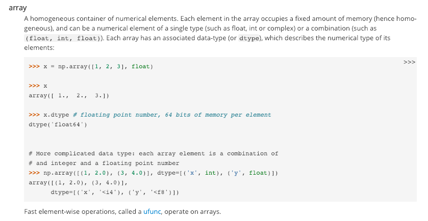

# Building an array with linspace

- Another function we can use to build an array is `np.linspace`

```python
y = np.linspace(-2, -1, 25)
print(y)
```

```
[-2.         -1.95833333 -1.91666667 -1.875      -1.83333333 -1.79166667
 -1.75       -1.70833333 -1.66666667 -1.625      -1.58333333 -1.54166667
 -1.5        -1.45833333 -1.41666667 -1.375      -1.33333333 -1.29166667
 -1.25       -1.20833333 -1.16666667 -1.125      -1.08333333 -1.04166667
 -1.        ]
```

- This function will return 25 numbers between -2 and -1

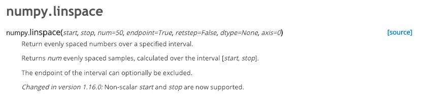

# Alternative ways of accessing functions

- If you are only going to use a handful of functions from a library, you can access functions in the following way:

```python
from numpy import array, linspace
x = array([0.01, 0.45, -0.3])
y = linspace(0, 1, 50)
```

- With this syntax, we can use `array` or `linspace` without the `np.` prefix

# Module completion checklist

| Objective | Complete |
| --- | --- |
| Illustrate NumPy objects in Python | **✔** |
| Explore NumPy array data types and implement more NumPy objects |  |

# NumPy array data types

| Data type | Description |
| --- | --- |
| `bool_` | Boolean (True or False) stored as a byte |
| `int_` | Default integer type (same as C `long`; normally either `int64` or `int32`) |
| `intc` | Identical to C `int` (normally `int32` or `int64`) |
| `intp` | Integer used for indexing (same as C `ssize_t`; normally either `int32` or `int64`) |
| `int8` | Byte (-128 to 127) |
| `int16` | Integer (-32768 to 32767) |
| `int32` | Integer (-2147483648 to 2147483647) |
| `int64` | Integer (-9223372036854775808 to 9223372036854775807) |

# NumPy array data types (cont’d)

[output not shown]

# Arrays vs. lists

- Unlike lists, NumPy arrays can hold values of only a single data type
- This makes arrays much more powerful for vectorized complex manipulations
- Let’s see what happens if we try to create an array from a list of mixed data types

```python
mixed_array = np.array([1, 2, "apple", "XYZ", 5.5])
print(mixed_array)
```

```
['1' '2' 'apple' 'XYZ' '5.5']
```

- **Question:** What do you think the data type of `mixed_array` will be?

# Arrays vs lists (cont’d)

- The answer is **<U21**, which is a data type for Unicode strings

```python
print(mixed_array.dtype)
```

```
<U21
```

- This means that all values in the initial list are cast into, or interpreted as, **string data** to maintain homogeneity
- Similarly, creating an array from a list of mixed integer and float values changes all elements to the **float** data type

```python
mixed_array = np.array([3, 12, 5.56])
print(mixed_array)
```

```
[ 3.   12.    5.56]
```

```python
print(mixed_array.dtype)
```

```
float64
```

- You can read more about NumPy data types [here](https://docs.scipy.org/doc/numpy/reference/arrays.dtypes.html)

# Arrays from sequences

- We can also create an array that contains a **sequence**, like a series of numbers
- To create the range of numbers of 0 to 50, use the `arange` command

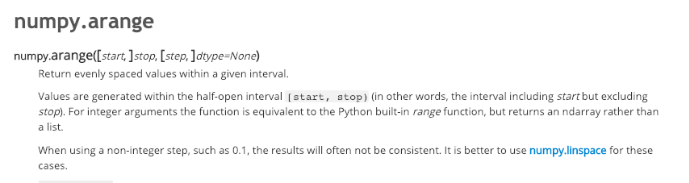

# Arrays from sequences (cont’d)

```python
rng = np.arange(0, 51)
print(rng)
```

```
[ 0  1  2  3  4  5  6  7  8  9 10 11 12 13 14 15 16 17 18 19 20 21 22 23
 24 25 26 27 28 29 30 31 32 33 34 35 36 37 38 39 40 41 42 43 44 45 46 47
 48 49 50]
```

- The last number in the range is one less than the value you provided, so we provide 51 to ensure that the last value is 50

# Arrays from sequences - using a step size

- To create a sequence of only some of the values in a range,like only the even values, we can specify a step size
- Let’s see what happens if we increase the step size from the default 1

```python
evens = np.arange(0, 23, 2)
print(evens)
```

```
[ 0  2  4  6  8 10 12 14 16 18 20 22]
```

```python
quarters = np.arange(0, 1, .25)  #<- contains 0 to 0.75
print(quarters)
```

```
[0.   0.25 0.5  0.75]
```

# Knowledge check

Link: https://forms.gle/kM4mV92NNiSMFLzbA

# Module completion checklist

| Objective | Complete |
| --- | --- |
| Illustrate NumPy objects in Python | **✔** |
| Explore NumPy array data types and implement more NumPy objects | **✔** |

# Congratulations on completing this module!

You are now ready to try Tasks 1-6 in the Exercise for this topic